# Modelling

- ## Loading the data and analysis libraries

```python
import matplotlib
from matplotlib import pyplot as plt
from matplotlib.pyplot import GridSpec
import numpy as np
import pandas as pd
import os, sys
import seaborn as sns
sns.set(style="ticks")
from pylab import rcParams
rcParams['figure.figsize'] = (7,5)
rcParams['figure.dpi'] = 120
rcParams['savefig.dpi'] = 120

rcParams['axes.facecolor'] = 'white'
matplotlib.style.use('ggplot')
import statsmodels.formula.api as smf
import statsmodels.api as sm
import missingno as msno
import seaborn as sns
import sklearn
from sklearn.preprocessing import StandardScaler,RobustScaler,MinMaxScaler

from sklearn.metrics import accuracy_score
from sklearn.preprocessing import PolynomialFeatures
from sklearn.linear_model import LinearRegression
from sklearn.model_selection import train_test_split
from sklearn.ensemble import RandomForestClassifier
from sklearn.svm import SVC
from sklearn.model_selection import cross_val_predict
from sklearn.metrics import mean_squared_error, r2_score
from sklearn.decomposition import PCA
from sklearn.pipeline import Pipeline
from sklearn.metrics import classification_report
from sklearn.neighbors import KNeighborsRegressor
from sklearn.preprocessing import StandardScaler
from sklearn.metrics import accuracy_score
from sklearn.preprocessing import PolynomialFeatures
from sklearn.linear_model import LinearRegression
from sklearn.model_selection import train_test_split
# from sklearn.neighbors import  KNeighborsRegressor
from sklearn.neighbors import KNeighborsClassifier
from sklearn.metrics import accuracy_score, confusion_matrix, precision_recall_fscore_support

%matplotlib inline
```

```python
ffs_players_salary = pd.read_csv('fmanual_feature_Select_players_salary.csv.gz',index_col=0)
```

```python
print(ffs_players_salary.shape)
ffs_players_salary.head()
```

```
(385, 12)
```

|  | Salary | MP | FG | FGA | P2A | P2 | FT | FTA | DRB | AST | TOV | PTS |
| --- | --- | --- | --- | --- | --- | --- | --- | --- | --- | --- | --- | --- |
| 0 | 19.863636 | 1914.0 | 314.0 | 726.0 | 500.0 | 246.0 | 137.0 | 203.0 | 338.0 | 215.0 | 94.0 | 833.0 |
| 1 | 2.329200 | 1368.0 | 202.0 | 496.0 | 293.0 | 122.0 | 62.0 | 72.0 | 111.0 | 193.0 | 75.0 | 546.0 |
| 3 | 1.618520 | 756.0 | 100.0 | 220.0 | 115.0 | 61.0 | 48.0 | 62.0 | 76.0 | 35.0 | 36.0 | 287.0 |
| 5 | 1.000000 | 293.0 | 30.0 | 75.0 | 28.0 | 16.0 | 9.0 | 13.0 | 28.0 | 14.0 | 7.0 | 83.0 |
| 6 | 28.000000 | 1848.0 | 289.0 | 654.0 | 390.0 | 200.0 | 55.0 | 73.0 | 320.0 | 244.0 | 65.0 | 722.0 |

### Normalization

```python
salary_col = ffs_players_salary['Salary']
salary_scaled = (salary_col-salary_col.min())/(salary_col.max()-salary_col.min()) *1000
ffs_players_salary['salary_scaled']= salary_scaled.copy()
ffs_players_salary.head()
```

|  | Salary | MP | FG | FGA | P2A | P2 | FT | FTA | DRB | AST | TOV | PTS | salary_scaled |
| --- | --- | --- | --- | --- | --- | --- | --- | --- | --- | --- | --- | --- | --- |
| 0 | 19.863636 | 1914.0 | 314.0 | 726.0 | 500.0 | 246.0 | 137.0 | 203.0 | 338.0 | 215.0 | 94.0 | 833.0 | 489.284837 |
| 1 | 2.329200 | 1368.0 | 202.0 | 496.0 | 293.0 | 122.0 | 62.0 | 72.0 | 111.0 | 193.0 | 75.0 | 546.0 | 49.622195 |
| 3 | 1.618520 | 756.0 | 100.0 | 220.0 | 115.0 | 61.0 | 48.0 | 62.0 | 76.0 | 35.0 | 36.0 | 287.0 | 31.802435 |
| 5 | 1.000000 | 293.0 | 30.0 | 75.0 | 28.0 | 16.0 | 9.0 | 13.0 | 28.0 | 14.0 | 7.0 | 83.0 | 16.293516 |
| 6 | 28.000000 | 1848.0 | 289.0 | 654.0 | 390.0 | 200.0 | 55.0 | 73.0 | 320.0 | 244.0 | 65.0 | 722.0 | 693.297974 |

- ## Regression

### We get a conclusion from the previous EDA that the Points(PTS), and Free Throw (FT) are primary indices for the player. I assumed the salary has a linear relationship with them.

### Create a Linear regression model for salary with the Points(PTS). It is easy to notice that using Linear and Polynomial models can not get an excellent R-squared result.

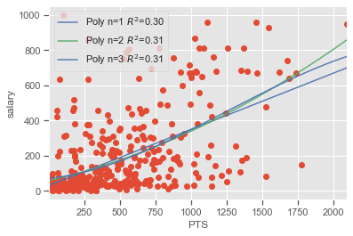

```
-------------
-------------
                            OLS Regression Results
==============================================================================
Dep. Variable:          salary_scaled   R-squared:                       0.310
Model:                            OLS   Adj. R-squared:                  0.305
Method:                 Least Squares   F-statistic:                     57.07
Date:                Fri, 17 Apr 2020   Prob (F-statistic):           1.72e-30
Time:                        19:32:43   Log-Likelihood:                -2561.7
No. Observations:                 385   AIC:                             5131.
Df Residuals:                     381   BIC:                             5147.
Df Model:                           3
Covariance Type:            nonrobust
=================================================================================
                    coef    std err          t      P>|t|      [0.025      0.975]
---------------------------------------------------------------------------------
Intercept        71.0929     26.739      2.659      0.008      18.519     123.667
PTS               0.0797      0.149      0.536      0.592      -0.213       0.372
I(PTS ** 2.0)     0.0003      0.000      1.255      0.210      -0.000       0.001
I(PTS ** 3.0) -7.081e-08   8.35e-08     -0.848      0.397   -2.35e-07    9.35e-08
==============================================================================
Omnibus:                       96.238   Durbin-Watson:                   1.976
Prob(Omnibus):                  0.000   Jarque-Bera (JB):              224.490
Skew:                           1.248   Prob(JB):                     1.79e-49
Kurtosis:                       5.786   Cond. No.                     2.81e+09
==============================================================================

Warnings:
[1] Standard Errors assume that the covariance matrix of the errors is correctly specified.
[2] The condition number is large, 2.81e+09. This might indicate that there are
strong multicollinearity or other numerical problems.
```

```python
plt.scatter( ffs_players_salary.PTS, ffs_players_salary.salary_scaled, s=10, alpha=0.3)
plt.xlabel('PTS')
plt.ylabel('salary')
x = pd.DataFrame({'PTS': np.linspace(ffs_players_salary.PTS.min(), ffs_players_salary.PTS.max(), len(ffs_players_salary.PTS)) })

x_min = ffs_players_salary.PTS.min()
x_max = ffs_players_salary.PTS.max()
plt.xlim(x_min,x_max)
plt.plot(ffs_players_salary.PTS,ffs_players_salary.salary_scaled, 'o')


poly_1 = smf.ols(formula='salary_scaled ~ 1 + PTS', data=ffs_players_salary).fit()
plt.plot(x, poly_1.predict(x), 'b-', label='Poly n=1 $R^2$=%.2f' % poly_1.rsquared,  alpha=0.9)

poly_2 = smf.ols(formula='salary_scaled ~ 1 + PTS + I(PTS ** 2.0)', data=ffs_players_salary).fit()
plt.plot(x, poly_2.predict(x), 'g-', label='Poly n=2 $R^2$=%.2f' % poly_2.rsquared, alpha=0.9)


poly_3 = smf.ols(formula='salary_scaled ~ 1 + PTS + I(PTS ** 2.0)+ I(PTS ** 3.0)', data=ffs_players_salary).fit()
plt.plot(x, poly_3.predict(x), 'b-', label='Poly n=3 $R^2$=%.2f' % poly_3.rsquared, alpha=0.9)

plt.legend()
plt.figure(dpi=180, figsize=(10, 6))

plt.show()
# print(poly_1.summary())
print("-------------")
# print(poly_2.summary())
print("-------------")
print(poly_3.summary())
```

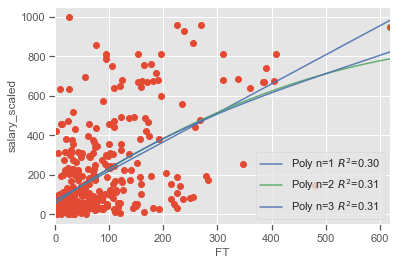

```
-------------
-------------
                            OLS Regression Results
==============================================================================
Dep. Variable:          salary_scaled   R-squared:                       0.309
Model:                            OLS   Adj. R-squared:                  0.303
Method:                 Least Squares   F-statistic:                     56.76
Date:                Fri, 17 Apr 2020   Prob (F-statistic):           2.38e-30
Time:                        19:32:47   Log-Likelihood:                -2562.1
No. Observations:                 385   AIC:                             5132.
Df Residuals:                     381   BIC:                             5148.
Df Model:                           3
Covariance Type:            nonrobust
================================================================================
                   coef    std err          t      P>|t|      [0.025      0.975]
--------------------------------------------------------------------------------
Intercept       54.1169     19.608      2.760      0.006      15.564      92.669
FT               1.9820      0.494      4.008      0.000       1.010       2.954
I(FT ** 2.0)    -0.0019      0.003     -0.702      0.483      -0.007       0.003
I(FT ** 3.0)  1.137e-06   3.67e-06      0.310      0.757   -6.08e-06    8.35e-06
==============================================================================
Omnibus:                       87.845   Durbin-Watson:                   1.959
Prob(Omnibus):                  0.000   Jarque-Bera (JB):              183.825
Skew:                           1.190   Prob(JB):                     1.21e-40
Kurtosis:                       5.407   Cond. No.                     3.29e+07
==============================================================================

Warnings:
[1] Standard Errors assume that the covariance matrix of the errors is correctly specified.
[2] The condition number is large, 3.29e+07. This might indicate that there are
strong multicollinearity or other numerical problems.
```

```python
plt.scatter( ffs_players_salary.FT, ffs_players_salary.salary_scaled, s=10, alpha=0.3)
plt.xlabel('FT')
plt.ylabel('salary_scaled')
x = pd.DataFrame({'FT': np.linspace(ffs_players_salary.FT.min(), ffs_players_salary.FT.max(), len(ffs_players_salary.FT)) })

x_min = ffs_players_salary.FT.min()
x_max = ffs_players_salary.FT.max()
plt.xlim(x_min,x_max)
plt.plot(ffs_players_salary.FT,ffs_players_salary.salary_scaled, 'o')


poly_1 = smf.ols(formula='salary_scaled ~ 1 + FT', data=ffs_players_salary).fit()
plt.plot(x, poly_1.predict(x), 'b-', label='Poly n=1 $R^2$=%.2f' % poly_1.rsquared,  alpha=0.9)

poly_2 = smf.ols(formula='salary_scaled ~ 1 + FT + I(FT ** 2.0)', data=ffs_players_salary).fit()
plt.plot(x, poly_2.predict(x), 'g-', label='Poly n=2 $R^2$=%.2f' % poly_2.rsquared, alpha=0.9)


poly_3 = smf.ols(formula='salary_scaled ~ 1 + FT + I(FT ** 2.0)+ I(FT ** 3.0)', data=ffs_players_salary).fit()
plt.plot(x, poly_3.predict(x), 'b-', label='Poly n=3 $R^2$=%.2f' % poly_3.rsquared, alpha=0.9)

plt.legend()
plt.figure(dpi=180, figsize=(10, 6))

plt.show()
# print(poly_1.summary())
print("-------------")
# print(poly_2.summary())
print("-------------")
print(poly_3.summary())
```

### Using all selected features to create a multiple-linear model and the model result is better than before. However, the accuracy of the model is too low and is not suitable for prediction.

```python
linear_model3 = smf.ols(formula='salary_scaled ~ 1 + MP+ FG+ FGA+ FT+ FTA+ DRB+ AST+TOV+ PTS + P2A+P2', data=ffs_players_salary).fit()
print(linear_model3.summary())
```

```
                            OLS Regression Results
==============================================================================
Dep. Variable:          salary_scaled   R-squared:                       0.396
Model:                            OLS   Adj. R-squared:                  0.380
Method:                 Least Squares   F-statistic:                     24.50
Date:                Fri, 17 Apr 2020   Prob (F-statistic):           1.64e-35
Time:                        19:32:48   Log-Likelihood:                -2536.2
No. Observations:                 385   AIC:                             5094.
Df Residuals:                     374   BIC:                             5138.
Df Model:                          10
Covariance Type:            nonrobust
==============================================================================
                 coef    std err          t      P>|t|      [0.025      0.975]
------------------------------------------------------------------------------
Intercept     72.5849     19.459      3.730      0.000      34.322     110.847
MP            -0.2233      0.045     -4.959      0.000      -0.312      -0.135
FG            -0.3962      0.259     -1.530      0.127      -0.905       0.113
FGA            0.5205      0.551      0.944      0.346      -0.564       1.605
FT             1.8069      1.004      1.799      0.073      -0.168       3.781
FTA           -1.1100      0.775     -1.432      0.153      -2.634       0.414
DRB            1.0111      0.181      5.578      0.000       0.655       1.367
AST            0.9669      0.197      4.919      0.000       0.580       1.353
TOV           -2.0806      0.659     -3.158      0.002      -3.376      -0.785
PTS            0.1543      0.461      0.335      0.738      -0.752       1.061
P2A           -0.3032      0.716     -0.423      0.672      -1.711       1.105
P2             0.4638      1.220      0.380      0.704      -1.935       2.863
==============================================================================
Omnibus:                       82.719   Durbin-Watson:                   1.914
Prob(Omnibus):                  0.000   Jarque-Bera (JB):              196.419
Skew:                           1.067   Prob(JB):                     2.23e-43
Kurtosis:                       5.773   Cond. No.                     1.92e+16
==============================================================================

Warnings:
[1] Standard Errors assume that the covariance matrix of the errors is correctly specified.
[2] The smallest eigenvalue is 2.5e-24. This might indicate that there are
strong multicollinearity problems or that the design matrix is singular.
```

### Use Scikit-learn to training multi-features.

```python
clear_players_salary = pd.read_csv('fmanual_feature_Select_players_salary.csv.gz',index_col=0)
clear_players_salary.head()
```

|  | Salary | MP | FG | FGA | P2A | P2 | FT | FTA | DRB | AST | TOV | PTS |
| --- | --- | --- | --- | --- | --- | --- | --- | --- | --- | --- | --- | --- |
| 0 | 19.863636 | 1914.0 | 314.0 | 726.0 | 500.0 | 246.0 | 137.0 | 203.0 | 338.0 | 215.0 | 94.0 | 833.0 |
| 1 | 2.329200 | 1368.0 | 202.0 | 496.0 | 293.0 | 122.0 | 62.0 | 72.0 | 111.0 | 193.0 | 75.0 | 546.0 |
| 3 | 1.618520 | 756.0 | 100.0 | 220.0 | 115.0 | 61.0 | 48.0 | 62.0 | 76.0 | 35.0 | 36.0 | 287.0 |
| 5 | 1.000000 | 293.0 | 30.0 | 75.0 | 28.0 | 16.0 | 9.0 | 13.0 | 28.0 | 14.0 | 7.0 | 83.0 |
| 6 | 28.000000 | 1848.0 | 289.0 | 654.0 | 390.0 | 200.0 | 55.0 | 73.0 | 320.0 | 244.0 | 65.0 | 722.0 |

```python
features_name = [ 'MP', 'FG', 'FGA', 'P2A', 'P2', 'FT', 'FTA', 'DRB', 'AST',
       'TOV', 'PTS']
X = clear_players_salary[features_name]
# X = clear_players_salary.iloc[:,5:]
salary_col = ffs_players_salary['Salary']
y = (salary_col-salary_col.min())/(salary_col.max()-salary_col.min())
# X
```

### Split the dataset to training and testing. Use 20% of the dataset to verify the model accuracy.

```python
X_train, X_test, y_train, y_test = train_test_split(X,y,test_size=0.2, random_state=888)
```

```python
print(X_train.shape)
print(y_train.shape)
print(X_test.shape)
print(y_test.shape)
```

```
(308, 11)
(308,)
(77, 11)
(77,)
```

### StandardScaler standardizes a feature by subtracting the mean and then scaling to unit variance. Unit variance means dividing all the values by the standard deviation.

```python
X_train = StandardScaler().fit(X_train).transform(X_train)
X_test = StandardScaler().fit(X_test).transform(X_test)
```

### Create a linear regression model to training all selected features by Skit-learn.

```python
poly_reg = Pipeline([
    ('poly',PolynomialFeatures(degree=1)),
#     ('poly',PolynomialFeatures(degree=2)),
    ('std_scaler',RobustScaler()),
    ('lin_reg',LinearRegression())
])
poly_reg.fit(X_train,y_train)
```

```
Pipeline(memory=None,
         steps=[('poly',
                 PolynomialFeatures(degree=1, include_bias=True,
                                    interaction_only=False, order='C')),
                ('std_scaler',
                 RobustScaler(copy=True, quantile_range=(25.0, 75.0),
                              with_centering=True, with_scaling=True)),
                ('lin_reg',
                 LinearRegression(copy_X=True, fit_intercept=True, n_jobs=None,
                                  normalize=False))],
         verbose=False)
```

### The model training result is 41%

```python
y_train_predict = poly_reg.predict(X_train)
print('Mean squared error: %.2f'% mean_squared_error(y_train, y_train_predict))
print('Coefficient of determination: %.2f'% r2_score(y_train, y_train_predict))
```

```
Mean squared error: 0.03
Coefficient of determination: 0.41
```

```python
y_test_predict = poly_reg.predict(X_test)
print('Mean squared error: %.2f'  % mean_squared_error(y_test, y_test_predict))
print('Coefficient of determination: %.2f'% r2_score(y_test, y_test_predict))
```

```
Mean squared error: 0.03
Coefficient of determination: 0.33
```

### Create a KNN regression model to training all selected features by Skit-learn.

### KNN has several params, and I try to search for the best params for the KNN model. The best group of params is using 3 neighbors, Minkowski, and distance.

```python
best_score = 0.0
best_k = 0
best_weights = ''
best_metric =''

weights = ['uniform','distance']
metric = ['minkowski','euclidean','manhattan','chebyshev']
for weight in weights:

    for metr in metric:

        for k in range(3, 20):
            knn_r = KNeighborsRegressor(algorithm='auto', leaf_size=30, metric= metr,
                   metric_params=None, n_jobs=None, n_neighbors=k, p=1,
                   weights= weight )

            knn_r.fit(X_train,y_train)
            y_train_predict = knn_r.predict(X_train)
            score = r2_score(y_train,y_train_predict)
            if score > best_score :
                best_score = score
                best_k = k
                best_metric = metr
                best_weights = weight

print('best_score:',best_score)
print('best_k:',best_k)
print('best_metric:',best_metric)
print('best_weights:',best_weights)
```

```
best_score: 1.0
best_k: 3
best_metric: minkowski
best_weights: distance
```

### Use above params to create the KNN model.

```python
knn_r = KNeighborsRegressor( metric='minkowski',
           metric_params=None, n_jobs=None, n_neighbors=3, p=1,
           weights='distance',
                          )
knn_r.fit(X_train,y_train)
```

```
KNeighborsRegressor(algorithm='auto', leaf_size=30, metric='minkowski',
                    metric_params=None, n_jobs=None, n_neighbors=3, p=1,
                    weights='distance')
```

### The model training result is 100%

```python
y_train_predict = knn_r.predict(X_train)
print('Mean squared error: %.2f'% mean_squared_error(y_train, y_train_predict))
print('Coefficient of determination: %.2f'% r2_score(y_train, y_train_predict))
knn_r.score(X_train, y_train)
```

```
Mean squared error: 0.00
Coefficient of determination: 1.00
```

```
1.0
```

### However, the testing result is only 19%—the model overfitting so obviously.

```python
y_test_predict = knn_r.predict(X_test)
print('Mean squared error: %.2f'  % mean_squared_error(y_test, y_test_predict))
print('Coefficient of determination: %.2f'% r2_score(y_test, y_test_predict))
knn_r.score(X_test, y_test)
```

```
Mean squared error: 0.04
Coefficient of determination: 0.19
```

```
0.18994515316828856
```

- ## Classifier

### In the above experiment, we could get a conclusion is that the dataset is not fit for regression methods. We could try classifier methods to predict the salary of the players.

```python
ffs_players_salary = pd.read_csv('fmanual_feature_Select_players_salary.csv.gz',index_col=0)
salary_col = ffs_players_salary['Salary']
salary_scaled = (salary_col-salary_col.min())/(salary_col.max()-salary_col.min())
ffs_players_salary['salary_scaled']= salary_scaled.copy()
ffs_players_salary.head()
```

|  | Salary | MP | FG | FGA | P2A | P2 | FT | FTA | DRB | AST | TOV | PTS | salary_scaled |
| --- | --- | --- | --- | --- | --- | --- | --- | --- | --- | --- | --- | --- | --- |
| 0 | 19.863636 | 1914.0 | 314.0 | 726.0 | 500.0 | 246.0 | 137.0 | 203.0 | 338.0 | 215.0 | 94.0 | 833.0 | 0.489285 |
| 1 | 2.329200 | 1368.0 | 202.0 | 496.0 | 293.0 | 122.0 | 62.0 | 72.0 | 111.0 | 193.0 | 75.0 | 546.0 | 0.049622 |
| 3 | 1.618520 | 756.0 | 100.0 | 220.0 | 115.0 | 61.0 | 48.0 | 62.0 | 76.0 | 35.0 | 36.0 | 287.0 | 0.031802 |
| 5 | 1.000000 | 293.0 | 30.0 | 75.0 | 28.0 | 16.0 | 9.0 | 13.0 | 28.0 | 14.0 | 7.0 | 83.0 | 0.016294 |
| 6 | 28.000000 | 1848.0 | 289.0 | 654.0 | 390.0 | 200.0 | 55.0 | 73.0 | 320.0 | 244.0 | 65.0 | 722.0 | 0.693298 |

### I could grouping the player to 4 levels as regular players, first players, stars and superstars by salary.

```python
conditions = [
        (ffs_players_salary['salary_scaled']<=0.2), # regular players
        (ffs_players_salary['salary_scaled']<=0.4),# first players
        (ffs_players_salary['salary_scaled']<=0.6),# stars
        (ffs_players_salary['salary_scaled']>0.8) # superstars
]
choices = [1, 2,3,4]
ffs_players_salary['Nominal'] = np.select(conditions, choices, default=3)
ffs_players_salary.head()
```

|  | Salary | MP | FG | FGA | P2A | P2 | FT | FTA | DRB | AST | TOV | PTS | salary_scaled | Nominal |
| --- | --- | --- | --- | --- | --- | --- | --- | --- | --- | --- | --- | --- | --- | --- |
| 0 | 19.863636 | 1914.0 | 314.0 | 726.0 | 500.0 | 246.0 | 137.0 | 203.0 | 338.0 | 215.0 | 94.0 | 833.0 | 0.489285 | 3 |
| 1 | 2.329200 | 1368.0 | 202.0 | 496.0 | 293.0 | 122.0 | 62.0 | 72.0 | 111.0 | 193.0 | 75.0 | 546.0 | 0.049622 | 1 |
| 3 | 1.618520 | 756.0 | 100.0 | 220.0 | 115.0 | 61.0 | 48.0 | 62.0 | 76.0 | 35.0 | 36.0 | 287.0 | 0.031802 | 1 |
| 5 | 1.000000 | 293.0 | 30.0 | 75.0 | 28.0 | 16.0 | 9.0 | 13.0 | 28.0 | 14.0 | 7.0 | 83.0 | 0.016294 | 1 |
| 6 | 28.000000 | 1848.0 | 289.0 | 654.0 | 390.0 | 200.0 | 55.0 | 73.0 | 320.0 | 244.0 | 65.0 | 722.0 | 0.693298 | 3 |

### The salary of most NBA players is still at a low level, and there are more players with an average salary and fewer players with a higher salary, which is also following a reasonable sense.

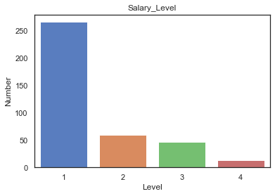

```python
bar=ffs_players_salary['Nominal'].value_counts()
sns.set(font_scale=2)
sns.set(style="white", palette="muted",color_codes=True)
ax = sns.barplot(x=bar.index,y=bar )
ax.set(xlabel='Level',ylabel='Number',title="Salary_Level")
plt.figure(dpi=80, figsize=(5, 3))
```

```python
features_name = [ 'MP', 'FG', 'FGA', 'P2A', 'P2', 'FT', 'FTA', 'DRB', 'AST','TOV', 'PTS']
X = ffs_players_salary[features_name]
y = ffs_players_salary['Nominal']
```

### Split the dataset to training and testing. Use 20% of the dataset to verify the model accuracy.

```python
X_train, X_test, y_train, y_test = train_test_split(X,y,test_size=0.2, random_state=888)
```

```python
print(X_train.shape)
print(y_train.shape)
print(X_test.shape)
print(y_test.shape)
```

```
(308, 11)
(308,)
(77, 11)
(77,)
```

### Create a KNN classifier model to training all selected features by Skit-learn.

```python
best_score = 0.0
best_k = 0
best_weights = ''
best_metric =''

weights = ['uniform','distance']
metric = ['minkowski','euclidean','manhattan','chebyshev']
for weight in weights:

    for metr in metric:

        for k in range(3, 20):
            knn = KNeighborsClassifier(algorithm='auto', leaf_size=30, metric= metr,
                   metric_params=None, n_jobs=None, n_neighbors=k, p=1,
                   weights= weight )

            knn.fit(X_train,y_train)
            y_train_predict = knn.predict(X_train)
            score = accuracy_score(y_train,y_train_predict)
            if score > best_score :
                best_score = score
                best_k = k
                best_metric = metr
                best_weights = weight

print('best_score:',best_score)
print('best_k:',best_k)
print('best_metric:',best_metric)
print('best_weights:',best_weights)
```

```
best_score: 1.0
best_k: 3
best_metric: minkowski
best_weights: distance
```

```python
knn = KNeighborsClassifier(algorithm='auto', leaf_size=30, metric='minkowski',
           metric_params=None, n_jobs=None, n_neighbors=3, p=1,
           weights='distance',
                          )
knn.fit(X_train,y_train)
```

```
KNeighborsClassifier(algorithm='auto', leaf_size=30, metric='minkowski',
                     metric_params=None, n_jobs=None, n_neighbors=3, p=1,
                     weights='distance')
```

### The model training result is 100%

```python
y_train_predict = knn.predict(X_train)
print ("KNN Train Accuracy: %.3f" % accuracy_score(y_train,y_train_predict))
```

```
KNN Train Accuracy: 1.000
```

### Although the accuracy of this model is only 63%, it can be used in predicting reluctantly.

```python
y_test_predict = knn.predict(X_test)
print ("KNN Test Accuracy: %.3f" % accuracy_score(y_test,y_test_predict))
```

```
KNN Test Accuracy: 0.636
```

### We could get the information from the confusion matrix that the model misclassified the group.

```
              precision    recall  f1-score   support

           1       0.74      0.83      0.78        54
           2       0.11      0.10      0.11        10
           3       0.43      0.25      0.32        12
           4       0.00      0.00      0.00         1

    accuracy                           0.64        77
   macro avg       0.32      0.30      0.30        77
weighted avg       0.60      0.64      0.61        77
```

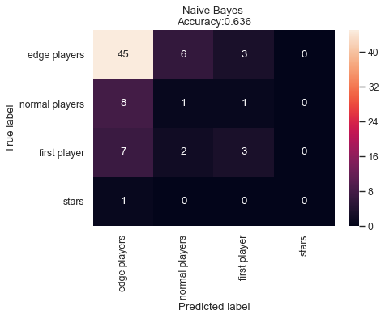

```python
print (classification_report(y_test,y_test_predict))
cm = confusion_matrix(y_test, y_test_predict)
cm_df = pd.DataFrame(cm,
                     index = ['edge players','normal players','first player','stars'],
                     columns = ['edge players','normal players','first player','stars'])

plt.figure(dpi=80, figsize=(6, 4))

sns.heatmap(cm_df, annot=True)
plt.title('Naive Bayes \nAccuracy:{0:.3f}'.format(accuracy_score(y_test, y_test_predict)))
plt.ylabel('True label')
plt.xlabel('Predicted label')
plt.show()
```

### Create a SVM model to training all selected features by Skit-learn.

```python
svm= SVC(C=1, kernel='rbf', degree=2, gamma=0.005,coef0=1,shrinking=True, tol=0.5,probability=False,
        max_iter=-1,)
svm.fit(X_train,y_train)
```

```
SVC(C=1, cache_size=200, class_weight=None, coef0=1,
    decision_function_shape='ovr', degree=2, gamma=0.005, kernel='rbf',
    max_iter=-1, probability=False, random_state=None, shrinking=True, tol=0.5,
    verbose=False)
```

### The model training result is 100%

```python
y_train_predict = svm.predict(X_train)
print ("SVM Train Accuracy: %.3f" % accuracy_score(y_train,y_train_predict))
```

```
SVM Train Accuracy: 1.000
```

```python
y_test_predict = svm.predict(X_test)
print("Logistic Test Accuracy: %.3f" % accuracy_score(y_test,y_test_predict))
```

```
Logistic Test Accuracy: 0.701
```

### We could get the information from the confusion matrix that the model misclassified the group.

```
              precision    recall  f1-score   support

           1       0.70      1.00      0.82        54
           2       0.00      0.00      0.00        10
           3       0.00      0.00      0.00        12
           4       0.00      0.00      0.00         1

    accuracy                           0.70        77
   macro avg       0.18      0.25      0.21        77
weighted avg       0.49      0.70      0.58        77
```

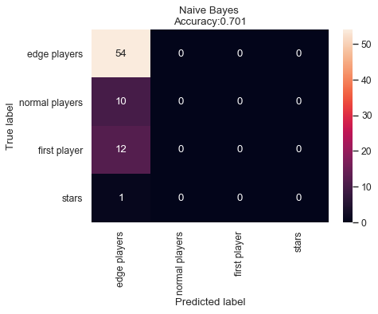

```python
print (classification_report(y_test,y_test_predict))
cm = confusion_matrix(y_test, y_test_predict)
cm_df = pd.DataFrame(cm,
                     index = ['edge players','normal players','first player','stars'],
                     columns = ['edge players','normal players','first player','stars'])

plt.figure(dpi=80, figsize=(6, 4))
sns.heatmap(cm_df, annot=True)
plt.title('Naive Bayes \nAccuracy:{0:.3f}'.format(accuracy_score(y_test, y_test_predict)))
plt.ylabel('True label')
plt.xlabel('Predicted label')
plt.show()
```

### Create a Random Forest classifier model to training all selected features by Skit-learn.

```python
forest = RandomForestClassifier(criterion='gini', max_leaf_nodes=None,
                                n_estimators = 100, random_state =1,
                                n_jobs =-1,verbose=True, oob_score=True)
forest.fit(X_train,y_train)
forest.oob_score_
```

```
[Parallel(n_jobs=-1)]: Using backend ThreadingBackend with 8 concurrent workers.
[Parallel(n_jobs=-1)]: Done  34 tasks      | elapsed:    0.1s
[Parallel(n_jobs=-1)]: Done 100 out of 100 | elapsed:    0.1s finished
```

```
0.672077922077922
```

### The model training result is 100%

```python
y_train_predict = forest.predict(X_train)
print ("Random Forest Train Accuracy: %.3f" % accuracy_score(y_train,y_train_predict))
```

```
Random Forest Train Accuracy: 1.000
```

```
[Parallel(n_jobs=8)]: Using backend ThreadingBackend with 8 concurrent workers.
[Parallel(n_jobs=8)]: Done  34 tasks      | elapsed:    0.0s
[Parallel(n_jobs=8)]: Done 100 out of 100 | elapsed:    0.0s finished
```

### The model testing result is 63%. The Random Forest model result is worse than SVM model.

```python
y_test_predict = forest.predict(X_test)
print("Random Forest Test Accuracy: %.3f" % accuracy_score(y_test,y_test_predict))
```

```
Random Forest Test Accuracy: 0.636
```

```
[Parallel(n_jobs=8)]: Using backend ThreadingBackend with 8 concurrent workers.
[Parallel(n_jobs=8)]: Done  34 tasks      | elapsed:    0.0s
[Parallel(n_jobs=8)]: Done 100 out of 100 | elapsed:    0.0s finished
```

### We also could find which feature is more important than others from the bar chart.

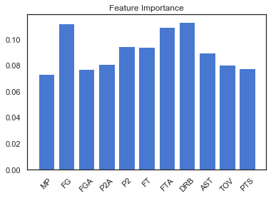

```python
plt.bar(range(len(X_train.columns.values)), forest.feature_importances_)
plt.xticks(range(len(X_train.columns.values)),X_train.columns.values, rotation= 45)

plt.title('Feature Importance')
```

### We could get the information from the confusion matrix that the model misclassified the group.

```
              precision    recall  f1-score   support

           1       0.73      0.85      0.79        54
           2       0.00      0.00      0.00        10
           3       0.25      0.17      0.20        12
           4       1.00      1.00      1.00         1

    accuracy                           0.64        77
   macro avg       0.50      0.50      0.50        77
weighted avg       0.56      0.64      0.60        77
```

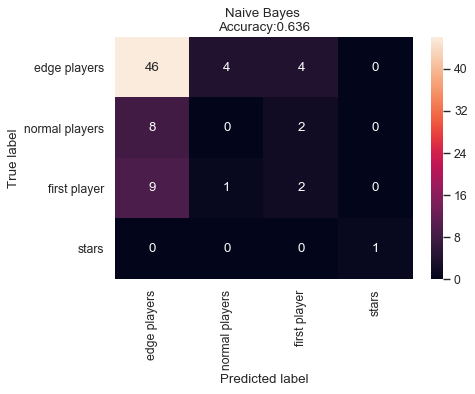

```python
print (classification_report(y_test,y_test_predict))
cm = confusion_matrix(y_test, y_test_predict)
cm_df = pd.DataFrame(cm,
                     index = ['edge players','normal players','first player','stars'],
                     columns = ['edge players','normal players','first player','stars'])

plt.figure(dpi=80, figsize=(6, 4))
sns.heatmap(cm_df, annot=True)
plt.title('Naive Bayes \nAccuracy:{0:.3f}'.format(accuracy_score(y_test, y_test_predict)))
plt.ylabel('True label')
plt.xlabel('Predicted label')
plt.show()
```

### By analyzing the accuracy of the above different models, it appears that the SVM model has higher accuracy(70%), followed by the Random Forest and KNN models, which has an accuracy of 63%. However, All of the regression models have poor fitting effects. Improving accuracy depends on more data and model tuning, which needs to be optimized more carefully later.